# CVD vs dementia, by age

```r
knitr::opts_chunk$set(echo = TRUE, warning=FALSE, message=F)
```

**Libraries**

```r
#install.packages("packages/rmarkdown_2.14.tar.gz", repos=NULL)

library(tidyverse)
library(survival)   # survival analysis
library(data.table) # fread() function
library(gridExtra)  # plots to grid
library(survminer)  # ggbased visualization and extra diagnostics
library(visdat)     # visualization of tibble and na's
library(kableExtra) # Pretty tables
library(tableone)   # Characteristics table
library(forestplot) # forestplot

fg_pheno_path <- "/finngen/library-red/finngen_R9/phenotype_1.0/data"
data_path <- "data"
fig_path <- "figs2"
#font_size <- 12

source("scripts/functions.R")
```

# 1 Data

## 1.1 Definitions

**Outcomes**

- Any dementia (KRA_PSY_DEMENTIA)
- Alzheimer disease (G6_ALZHEIMER)
- Vascular dementia (F5_VASCDEM)

**Exposures**

- Heart failure (I9_HEARTFAIL_ALLCAUSE)
- Atrial fibrillation (I9_AF)
- Myocardial infarction (I9_MI)
- Peripheral arterial disease (I9_PAD)
- Stroke (I9_STR)
- TIA (I9_TIA)

**Covariates**

Age is not included as we do not have explicit baseline.  
Dementia age is taken account by using age as time scale. Birth year is included to take account cohort effects. Disease covariates are treated as time varied covariates.

- Birth year, (SD)
- Smoking, n (%)

Disease covariates

- Obesity (E4_OBESITY), n (%)
- Hyperlipidemia (E4_HYPERLIPMIX|RX_STATIN), n (%)
- Chronic kidney disease (N14_CHRONKIDNEYDIS), n (%)
- Hypertension (I9_HYPERTENSION), n (%)
- Diabetes (E4_DIABETES), n (%)
- Alcohol abuse (AUD), n (%)

## 1.2 Variable lists

```r
nicenames <- c(DEMENTIA = "Any dementia", ALZHEIMER = "Alzheimer disase", VASCDEM = "Vascular dementia",
               AF_TDC = "Atrial fibrillation", OBESITY_TDC = "Obesity",
               HYPLIP_WIDE_TDC = "Hyperlipidemia", HEARTFAIL_ALLCAUSE_TDC="Heart failure",
               MI_TDC = "Myocardial infarction", CHRONKIDNEYDIS_TDC = "Chronic kidney disease",
               HYPERTENSION_TDC = "Hypertension", DIABETES_TDC = "Diabetes", STR_TDC = "Stroke",
               STR_EMBOLIC_TDC = "Embolic stroke", TIA_TDC = "TIA",
               AUD_TDC = "Alcohol abuse", PAD_TDC = "PAD")

#Outcomes
names_ep <- list("DEMENTIA", "ALZHEIMER", "VASCDEM")
ep_age <-   str_replace(unlist(names_ep), "(.*)", "\\1_AGE")

#time dependent variables
tdc_vars <- c("AF_TDC","OBESITY_TDC", "HYPLIP_WIDE_TDC", "HEARTFAIL_ALLCAUSE_TDC", "MI_TDC",
             "CHRONKIDNEYDIS_TDC", "HYPERTENSION_TDC", "DIABETES_TDC", "STR_TDC",
             "TIA_TDC", "AUD_TDC", "PAD_TDC")
tdc_vars_ever <- str_remove(tdc_vars, "_TDC")
tdc_vars_age <- str_replace(tdc_vars, "_TDC", "_AGE")

tdc_vars2 <- c("HEARTFAIL_ALLCAUSE_TDC", "AF_TDC", "MI_TDC", "PAD_TDC", "STR_TDC" , "TIA_TDC")
tdc_vars2_ever <- str_remove(tdc_vars2, "_TDC")
tdc_vars2_year <- str_replace(tdc_vars2, "_TDC", "_YEAR")

#Other covariates
oth_covs <- c("BIRTH_YEAR", "SMOKED")
oth_covs2 <- c(oth_covs, "OBESITY_TDC",  "HYPLIP_WIDE_TDC", "CHRONKIDNEYDIS_TDC", "HYPERTENSION_TDC", "DIABETES_TDC", "AUD_TDC")


#Study start year
start_year = 1998

#Age cutoff
age_cutoff = 57
```

## 1.3 Preselect phenotype columns

Entries of interest from endpoint file are preselected at ‘rather big machine’, because the original phenotype file is very large.

```r
pheno_cols <- fread("data/variables.txt") %>%
  mutate(col_age = str_glue("{column}_AGE")) %>%
  mutate(col_year = str_glue("{column}_YEAR"))

pheno_cols_all <- c(pheno_cols$column, pheno_cols$col_age, pheno_cols$col_year)

pheno_tmp <- fread(str_glue("{fg_pheno_path}/finngen_R9_endpoint_1.0.txt.gz")) %>%
  select(FINNGENID, FU_END_AGE, all_of(pheno_cols_all))

fwrite(pheno_tmp, 'data/finngen_R9_myvars.tsv.gz', sep='\t')
```

## 1.4 Read in and preprocess

```r
#disease variables
phenotypes <- fread("data/finngen_R9_myvars.tsv.gz") %>%

  #Names are simplified
  rename_at(vars(matches("^[A-Z][0-9]+_")), list(~str_remove(., "^[A-Z][0-9]+_"))) %>%
  rename_at(vars(starts_with('KRA_PSY_')), list(~str_remove(., "KRA_PSY_"))) %>%
  rename_at(vars(starts_with('C_')), list(~str_remove(., "C_"))) %>%
  rename_at(vars(starts_with('DM_')), list(~str_remove(., "DM_"))) %>%
  rename_at(vars(starts_with('RX_')), list(~str_remove(., "RX_"))) %>%

  #Wider definition of hypercholesterolaemia, includes also statin medication
  mutate(HYPLIP_WIDE = if_else(HYPERLIPMIX == 1 | STATIN == 1, 1L, 0L)) %>%
  rowwise() %>%
    mutate(HYPLIP_WIDE_AGE = min(HYPERLIPMIX_AGE, STATIN_AGE)) %>%
  ungroup() %>%

  #Change NA -> 0 for disease variables
  #FinnGen data is constructed for GWASes, where similar diseases need to be removed from controls
  #This does not apply to present study
   mutate_at(c(unlist(names_ep), tdc_vars_ever), ~if_else(is.na(.), 0L, .))


#other covariates
phenomin <- fread(str_glue("{fg_pheno_path}/finngen_R9_minimum_1.0.txt.gz")) %>%
  select("FINNGENID", contains("BL_"), "SEX", "SMOKE3", "SMOKE_AGE", "movedabroad") %>%
  #smoking: ever-never according phenotype minimal file
  mutate(SMOKED = if_else(SMOKE3 == "never", 0, 1)) %>%
  #Approximate birth year calculated from BL_YEAR and BL_AGE
  mutate(BIRTH_YEAR = BL_YEAR - BL_AGE,     #genotyping year and age
         START_AGE = if_else(floor(BIRTH_YEAR) < start_year, start_year-BIRTH_YEAR, 0),
         BIRTH_YEAR = as.integer(floor(BIRTH_YEAR)))

#Imputed sex is from genotyped dataset
sex_in <- fread(str_glue("/finngen/library-red/finngen_R9/analysis_covariates/R9_COV_V1.FID.txt.gz")) %>%
  select(IID, SEX_IMPUTED) %>%
  rename(FINNGENID = IID) %>%
  rename(WOMEN = SEX_IMPUTED)
```

## 1.5 Combine & filter

**All**

```r
df.tmp1 <-phenomin %>%
  right_join(sex_in, by = "FINNGENID") %>%   #This represent official genotyped dataset
  left_join(phenotypes, by = "FINNGENID") %>%
  mutate(AGE_CL = if_else(START_AGE < age_cutoff, "young", "old") %>% as.factor)
df.tmp1 %>% select("AGE_CL") %>% summary
```

```
##    AGE_CL
##  old  : 65020
##  young:312257
```

**Remove individual with no “FU_END_AGE” i.e. individuals missing from endpoint-file**

```r
#Remove individual with no "FU_END_AGE" i.e. individuals missing from endpoint-file
df.tmp2 <- df.tmp1 %>%
  filter(!is.na(FU_END_AGE))
df.tmp2 %>% select("AGE_CL") %>% summary
```

```
##    AGE_CL
##  old  : 65020
##  young:312257
```

**Remove if no smoking record**

```r
#Remove individual if no smoking record
df.tmp3 <- df.tmp2 %>%
  filter(!is.na(SMOKED))
df.tmp3 %>% select("AGE_CL") %>% summary
```

```
##    AGE_CL
##  old  : 46478
##  young:175284
```

Full register coverage starts from this year.

```r
#Remove individual if any dementia before 'start year'
df <- df.tmp3 %>%
  filter(DEMENTIA_AGE > START_AGE+0.003 & ALZHEIMER_AGE > START_AGE+0.003 & VASCDEM_AGE > START_AGE+0.003)
  #0.003 years = one day; coxph would inteprete very short time difference 0 time followup
df %>% select("AGE_CL") %>% summary
```

```
##    AGE_CL
##  old  : 43039
##  young:175153
```

## 1.6 Variables to list by outcome

Minor formatting

```r
#Minor formatting for more clear summaries etc
df <- df %>%
  mutate_at(unlist(names_ep), ~as.integer(as.character(.)) ) %>%
  mutate_at(c(tdc_vars_ever), as.factor) %>%
  select(FINNGENID, WOMEN, all_of(oth_covs), FU_END_AGE, START_AGE, BIRTH_YEAR, all_of(unlist(names_ep)), all_of(ep_age),
         all_of(tdc_vars_ever), all_of(tdc_vars_age))
```

**As time varied variable**

```r
df.list.tdc <- lapply(names_ep, as.null) %>% setNames(names_ep)

for(ep in unlist(names_ep)){

  #ep = "DEMENTIA"
  ep_age_tmp <- as.character(str_glue("{ep}_AGE"))
  dfi <- df  #%>% slice(1:30)
  #print(ep)

  dfi.tmp   <- tmerge(data1=dfi,   data2=dfi, id=FINNGENID, tstart = START_AGE, tstop = get(ep_age_tmp),
                      event=event(get(ep_age_tmp), get(ep)))

  for(var in tdc_vars_ever){
    #var %>% print()
    dfi.tmp  <- tmerge(data1=dfi.tmp, data2=dfi, id=FINNGENID, tdc_var = tdc(get(str_glue("{var}_AGE")))) %>%
      rename(!!str_glue("{var}_TDC") := tdc_var)
  }

  df.list.tdc[[ep]] <- dfi.tmp %>%
    filter(tstop > tstart+0.003) %>%  #0.003 years = one day; coxph would inteprete very short time difference 0 time followup
    mutate(time_test = tstop - tstart)
}
```

**Divide by age**

We will divide individuals to two groups by start age. Our population is relatively young, so we will divide by fourth age quintile.

```r
df %>% pull(START_AGE) %>% quantile(probs=c(0,0.2,0.4,0.6,0.8,1))
```

```
##    0%   20%   40%   60%   80%  100%
##  0.00 22.37 36.35 46.38 56.83 97.89
```

```r
#Young
df.list.tdc.y <- lapply(df.list.tdc, function(dfi) {dfi %>% filter(START_AGE < age_cutoff)})
#Old
df.list.tdc.o <- lapply(df.list.tdc, function(dfi) {dfi %>% filter(START_AGE>=age_cutoff)})
```

Age cutoff: 57 years.

## 1.7 Cross tables

### 1.7.1 Young

```r
lapply(names_ep, function(ep){
  cbind(extract_nN_tdc(df.list.tdc.y[[ep]], ep, tdc_vars2)[,1:5], outcome=ep)
}) %>% setNames(names_ep) %>%
  bind_rows() %>%
  relocate(outcome) %>%
  rename(exposure = names) %>%
  my.kable()
```

| outcome | exposure | event_exp | cens_exp | event_nexp | cens_nexp |
| --- | --- | --- | --- | --- | --- |
| DEMENTIA | HEARTFAIL_ALLCAUSE_TDC | 143 | 5946 | 1707 | 167357 |
| DEMENTIA | AF_TDC | 267 | 13156 | 1583 | 160147 |
| DEMENTIA | MI_TDC | 161 | 7072 | 1689 | 166231 |
| DEMENTIA | PAD_TDC | 109 | 4575 | 1741 | 168728 |
| DEMENTIA | STR_TDC | 237 | 7079 | 1613 | 166224 |
| DEMENTIA | TIA_TDC | 146 | 5920 | 1704 | 167383 |
| ALZHEIMER | HEARTFAIL_ALLCAUSE_TDC | 82 | 6037 | 953 | 168081 |
| ALZHEIMER | AF_TDC | 151 | 13327 | 884 | 160791 |
| ALZHEIMER | MI_TDC | 88 | 7164 | 947 | 166954 |
| ALZHEIMER | PAD_TDC | 63 | 4649 | 972 | 169469 |
| ALZHEIMER | STR_TDC | 121 | 7254 | 914 | 166864 |
| ALZHEIMER | TIA_TDC | 83 | 6016 | 952 | 168102 |
| VASCDEM | HEARTFAIL_ALLCAUSE_TDC | 32 | 6106 | 181 | 168834 |
| VASCDEM | AF_TDC | 54 | 13455 | 159 | 161485 |
| VASCDEM | MI_TDC | 27 | 7232 | 186 | 167708 |
| VASCDEM | PAD_TDC | 29 | 4691 | 184 | 170249 |
| VASCDEM | STR_TDC | 76 | 7324 | 137 | 167616 |
| VASCDEM | TIA_TDC | 32 | 6078 | 181 | 168862 |

### 1.7.2 Old

```r
lapply(names_ep, function(ep){
  cbind(extract_nN_tdc(df.list.tdc.o[[ep]], ep, tdc_vars2)[,1:5], outcome=ep)
}) %>% setNames(names_ep) %>%
  bind_rows() %>%
  relocate(outcome) %>%
  rename(exposure = names) %>%
  my.kable()
```

| outcome | exposure | event_exp | cens_exp | event_nexp | cens_nexp |
| --- | --- | --- | --- | --- | --- |
| DEMENTIA | HEARTFAIL_ALLCAUSE_TDC | 1676 | 9078 | 6175 | 26110 |
| DEMENTIA | AF_TDC | 2025 | 11692 | 5826 | 23496 |
| DEMENTIA | MI_TDC | 1352 | 7601 | 6499 | 27587 |
| DEMENTIA | PAD_TDC | 809 | 5003 | 7042 | 30185 |
| DEMENTIA | STR_TDC | 1425 | 6701 | 6426 | 28487 |
| DEMENTIA | TIA_TDC | 923 | 3970 | 6928 | 31218 |
| ALZHEIMER | HEARTFAIL_ALLCAUSE_TDC | 1054 | 9874 | 4234 | 27877 |
| ALZHEIMER | AF_TDC | 1275 | 12634 | 4013 | 25117 |
| ALZHEIMER | MI_TDC | 879 | 8206 | 4409 | 29545 |
| ALZHEIMER | PAD_TDC | 505 | 5402 | 4783 | 32349 |
| ALZHEIMER | STR_TDC | 768 | 7571 | 4520 | 30180 |
| ALZHEIMER | TIA_TDC | 582 | 4394 | 4706 | 33357 |
| VASCDEM | HEARTFAIL_ALLCAUSE_TDC | 383 | 10813 | 1023 | 30820 |
| VASCDEM | AF_TDC | 454 | 13827 | 952 | 27806 |
| VASCDEM | MI_TDC | 290 | 9017 | 1116 | 32616 |
| VASCDEM | PAD_TDC | 205 | 5785 | 1201 | 35848 |
| VASCDEM | STR_TDC | 518 | 8100 | 888 | 33533 |
| VASCDEM | TIA_TDC | 246 | 4844 | 1160 | 36789 |

## 1.8 Characteristics

Separate tables are generated for different outcomes, because filtering of prevalents and setting disease covariates as ‘prior’ are done separately for each outcome.

### 1.8.1 Dementia

```r
ep <- "DEMENTIA"
vars <- c(ep, "START_AGE", "END_AGE", oth_covs, tdc_vars)
fact_vars <- c(ep, "SMOKED", tdc_vars)

#Young
df.tmp <- df.list.tdc.y[[ep]] %>%
  select(FINNGENID, START_AGE, all_of(c(ep, str_glue("{ep}_AGE"), oth_covs, tdc_vars))) %>%
  group_by(FINNGENID) %>%
  summarise_all(max) %>%   #For 'tdc variables'  we want maximum (1 if any of the rows have 1), others should be the same in all rows an individual.
  rename(END_AGE = str_glue("{ep}_AGE"))

table.y <- CreateTableOne(vars=vars, data=df.tmp, factorVars = fact_vars, test=F) %>%
  print(dropEqual=T, printToggle=F, contDigits=1)
colnames(table.y) <- c("Young")


#Old
df.tmp <- df.list.tdc.o[[ep]] %>%
  select(FINNGENID, START_AGE, all_of(c(ep, str_glue("{ep}_AGE"), oth_covs, tdc_vars))) %>%
  group_by(FINNGENID) %>%
  summarise_all(max) %>%   #For 'tdc variables'  we want maximum (1 if any of the rows have 1), others should be the same in all rows an individual.
  rename(END_AGE = str_glue("{ep}_AGE"))

table.o <- CreateTableOne(vars=vars, data=df.tmp, factorVars = fact_vars, test=F) %>%
  print(dropEqual=T, printToggle=F, contDigits=1)
colnames(table.o) <- c("Old")


#Combine
cbind(table.y, table.o) %>%
  my.kable
```

|  | Young | Old |
| --- | --- | --- |
| n | 175153 | 43039 |
| DEMENTIA (%) | 1850 ( 1.1) | 7851 (18.2) |
| START_AGE (mean (SD)) | 33.8 (15.4) | 65.2 (5.8) |
| END_AGE (mean (SD)) | 56.8 (15.3) | 81.8 (6.4) |
| BIRTH_YEAR (mean (SD)) | 1963.8 (15.4) | 1932.3 (5.8) |
| SMOKED (%) | 83811 (47.9) | 25651 (59.6) |
| AF_TDC (%) | 13423 ( 7.7) | 13717 (31.9) |
| OBESITY_TDC (%) | 11206 ( 6.4) | 1205 ( 2.8) |
| HYPLIP_WIDE_TDC (%) | 51514 (29.4) | 24144 (56.1) |
| HEARTFAIL_ALLCAUSE_TDC (%) | 6089 ( 3.5) | 10754 (25.0) |
| MI_TDC (%) | 7233 ( 4.1) | 8953 (20.8) |
| CHRONKIDNEYDIS_TDC (%) | 2624 ( 1.5) | 2453 ( 5.7) |
| HYPERTENSION_TDC (%) | 40182 (22.9) | 23306 (54.2) |
| DIABETES_TDC (%) | 25535 (14.6) | 11409 (26.5) |
| STR_TDC (%) | 7316 ( 4.2) | 8126 (18.9) |
| TIA_TDC (%) | 6066 ( 3.5) | 4893 (11.4) |
| AUD_TDC (%) | 8522 ( 4.9) | 1752 ( 4.1) |
| PAD_TDC (%) | 4684 ( 2.7) | 5812 (13.5) |

### 1.8.2 Alzheimer

```r
ep <- "ALZHEIMER"
vars <- c(ep, "START_AGE", "END_AGE", oth_covs, tdc_vars)
fact_vars <- c(ep, "SMOKED", tdc_vars)

#Young
df.tmp <- df.list.tdc.y[[ep]] %>%
  select(FINNGENID, START_AGE, all_of(c(ep, str_glue("{ep}_AGE"), oth_covs, tdc_vars))) %>%
  group_by(FINNGENID) %>%
  summarise_all(max) %>%   #For 'tdc variables'  we want maximum (1 if any of the rows have 1), others should be the same in all rows an individual.
  rename(END_AGE = str_glue("{ep}_AGE"))

table.y <- CreateTableOne(vars=vars, data=df.tmp, factorVars = fact_vars, test=F) %>%
  print(dropEqual=T, printToggle=F, contDigits=1)
colnames(table.y) <- c("Young")


#Old
df.tmp <- df.list.tdc.o[[ep]] %>%
  select(FINNGENID, START_AGE, all_of(c(ep, str_glue("{ep}_AGE"), oth_covs, tdc_vars))) %>%
  group_by(FINNGENID) %>%
  summarise_all(max) %>%   #For 'tdc variables'  we want maximum (1 if any of the rows have 1), others should be the same in all rows an individual.
  rename(END_AGE = str_glue("{ep}_AGE"))

table.o <- CreateTableOne(vars=vars, data=df.tmp, factorVars = fact_vars, test=F) %>%
  print(dropEqual=T, printToggle=F, contDigits=1)
colnames(table.o) <- c("Old")


#Combine
cbind(table.y, table.o) %>%
  my.kable
```

|  | Young | Old |
| --- | --- | --- |
| n | 175153 | 43039 |
| ALZHEIMER (%) | 1035 ( 0.6) | 5288 (12.3) |
| START_AGE (mean (SD)) | 33.8 (15.4) | 65.2 (5.8) |
| END_AGE (mean (SD)) | 56.8 (15.3) | 82.0 (6.4) |
| BIRTH_YEAR (mean (SD)) | 1963.8 (15.4) | 1932.3 (5.8) |
| SMOKED (%) | 83811 (47.9) | 25651 (59.6) |
| AF_TDC (%) | 13478 ( 7.7) | 13909 (32.3) |
| OBESITY_TDC (%) | 11229 ( 6.4) | 1215 ( 2.8) |
| HYPLIP_WIDE_TDC (%) | 51611 (29.5) | 24246 (56.3) |
| HEARTFAIL_ALLCAUSE_TDC (%) | 6119 ( 3.5) | 10928 (25.4) |
| MI_TDC (%) | 7252 ( 4.1) | 9085 (21.1) |
| CHRONKIDNEYDIS_TDC (%) | 2641 ( 1.5) | 2535 ( 5.9) |
| HYPERTENSION_TDC (%) | 40268 (23.0) | 23495 (54.6) |
| DIABETES_TDC (%) | 25603 (14.6) | 11481 (26.7) |
| STR_TDC (%) | 7375 ( 4.2) | 8339 (19.4) |
| TIA_TDC (%) | 6099 ( 3.5) | 4976 (11.6) |
| AUD_TDC (%) | 8560 ( 4.9) | 1788 ( 4.2) |
| PAD_TDC (%) | 4712 ( 2.7) | 5907 (13.7) |

### 1.8.3 Vascular dementia

```r
ep <- "VASCDEM"
vars <- c(ep, "START_AGE", "END_AGE", oth_covs, tdc_vars)
fact_vars <- c(ep, "SMOKED", tdc_vars)

#Young
df.tmp <- df.list.tdc.y[[ep]] %>%
  select(FINNGENID, START_AGE, all_of(c(ep, str_glue("{ep}_AGE"), oth_covs, tdc_vars))) %>%
  group_by(FINNGENID) %>%
  summarise_all(max) %>%   #For 'tdc variables'  we want maximum (1 if any of the rows have 1), others should be the same in all rows an individual.
  rename(END_AGE = str_glue("{ep}_AGE"))

table.y <- CreateTableOne(vars=vars, data=df.tmp, factorVars = fact_vars, test=F) %>%
  print(dropEqual=T, printToggle=F, contDigits=1)
colnames(table.y) <- c("Young")


#Old
df.tmp <- df.list.tdc.o[[ep]] %>%
  select(FINNGENID, START_AGE, all_of(c(ep, str_glue("{ep}_AGE"), oth_covs, tdc_vars))) %>%
  group_by(FINNGENID) %>%
  summarise_all(max) %>%   #For 'tdc variables'  we want maximum (1 if any of the rows have 1), others should be the same in all rows an individual.
  rename(END_AGE = str_glue("{ep}_AGE"))

table.o <- CreateTableOne(vars=vars, data=df.tmp, factorVars = fact_vars, test=F) %>%
  print(dropEqual=T, printToggle=F, contDigits=1)
colnames(table.o) <- c("Old")


#Combine
cbind(table.y, table.o) %>%
  my.kable
```

|  | Young | Old |
| --- | --- | --- |
| n | 175153 | 43039 |
| VASCDEM (%) | 213 ( 0.1) | 1406 ( 3.3) |
| START_AGE (mean (SD)) | 33.8 (15.4) | 65.2 (5.8) |
| END_AGE (mean (SD)) | 56.8 (15.3) | 82.3 (6.4) |
| BIRTH_YEAR (mean (SD)) | 1963.8 (15.4) | 1932.3 (5.8) |
| SMOKED (%) | 83811 (47.9) | 25651 (59.6) |
| AF_TDC (%) | 13509 ( 7.7) | 14281 (33.2) |
| OBESITY_TDC (%) | 11228 ( 6.4) | 1230 ( 2.9) |
| HYPLIP_WIDE_TDC (%) | 51630 (29.5) | 24332 (56.5) |
| HEARTFAIL_ALLCAUSE_TDC (%) | 6138 ( 3.5) | 11196 (26.0) |
| MI_TDC (%) | 7259 ( 4.1) | 9307 (21.6) |
| CHRONKIDNEYDIS_TDC (%) | 2648 ( 1.5) | 2620 ( 6.1) |
| HYPERTENSION_TDC (%) | 40311 (23.0) | 23834 (55.4) |
| DIABETES_TDC (%) | 25612 (14.6) | 11573 (26.9) |
| STR_TDC (%) | 7400 ( 4.2) | 8618 (20.0) |
| TIA_TDC (%) | 6110 ( 3.5) | 5090 (11.8) |
| AUD_TDC (%) | 8560 ( 4.9) | 1799 ( 4.2) |
| PAD_TDC (%) | 4720 ( 2.7) | 5990 (13.9) |

# 2 Analysis

## 2.1 Incidence

**Young**

Incidence rates per 1000 patient-years

```r
#for each outcome...
lapply(names_ep, function(ep){

  df.tmp.y <- df %>%
      filter(START_AGE < age_cutoff) %>%
      #calculate follow-up time for each individual
      mutate(FU_TIME = get(str_glue("{ep}_AGE")) - START_AGE) %>%
      #Set ourcomes as 0, if after outcome
         #At survival analysis this is taken care when tdc variables are created
      mutate_at(tdc_vars2_ever, ~as.numeric(as.character(.))) %>%
      mutate(across(all_of(tdc_vars2_ever),
                  ~if_else(get(str_glue("{cur_column()}_AGE")) >= get(str_glue("{ep}_AGE")), 0L, .)))

  #for each exposure...
  lapply(tdc_vars2_ever, function(var) {
    name1 = quo_name(str_glue("{var}_1"))
    name0 = quo_name(str_glue("{var}_0"))
    df.tmp.y %>%
      group_by_at(var) %>%
        #Calculate incidence rate
        summarise(INC=(sum(get(ep))/sum(FU_TIME))*1000) %>%
        #change format
        pivot_wider(names_from=all_of(var), values_from=INC) %>%
        rename(!!name1 := `1`, !!name0 := `0`)
  }) %>%
    bind_cols() %>%
    mutate(outcome=ep)
}) %>%
  bind_rows() %>%
  relocate(outcome) %>%
  rename(HF_0 = HEARTFAIL_ALLCAUSE_0, HF_1 = HEARTFAIL_ALLCAUSE_1 ) %>%
  mutate_if(is.numeric, ~round(.,2)) %>%
  my.kable()
```

| outcome | HF_0 | HF_1 | AF_0 | AF_1 | MI_0 | MI_1 | PAD_0 | PAD_1 | STR_0 | STR_1 | TIA_0 | TIA_1 |
| --- | --- | --- | --- | --- | --- | --- | --- | --- | --- | --- | --- | --- |
| DEMENTIA | 0.44 | 1.05 | 0.43 | 0.87 | 0.44 | 0.99 | 0.44 | 1.03 | 0.42 | 1.43 | 0.44 | 1.05 |
| ALZHEIMER | 0.24 | 0.60 | 0.24 | 0.49 | 0.24 | 0.53 | 0.25 | 0.59 | 0.24 | 0.72 | 0.24 | 0.59 |
| VASCDEM | 0.05 | 0.23 | 0.04 | 0.17 | 0.05 | 0.17 | 0.05 | 0.27 | 0.04 | 0.45 | 0.05 | 0.23 |

**Old**

Incidence rates per 1000 patient-years

```r
#for each outcome...
lapply(names_ep, function(ep){

  df.tmp.y <- df %>%
      filter(START_AGE >= age_cutoff) %>%
      #calculate follow-up time for each individual
      mutate(FU_TIME = get(str_glue("{ep}_AGE")) - START_AGE) %>%
      #Set ourcomes as 0, if after outcome
         #At survival analysis this is taken care when tdc variables are created
      mutate_at(tdc_vars2_ever, ~as.numeric(as.character(.))) %>%
      mutate(across(all_of(tdc_vars2_ever),
                  ~if_else(get(str_glue("{cur_column()}_AGE")) >= get(str_glue("{ep}_AGE")), 0L, .)))

  #for each exposure...
  lapply(tdc_vars2_ever, function(var) {
    name1 = quo_name(str_glue("{var}_1"))
    name0 = quo_name(str_glue("{var}_0"))
    df.tmp.y %>%
      group_by_at(var) %>%
        #Calculate incidence rate
        summarise(INC=(sum(get(ep))/sum(FU_TIME))*1000) %>%
        #change format
        pivot_wider(names_from=all_of(var), values_from=INC) %>%
        rename(!!name1 := `1`, !!name0 := `0`)
  }) %>%
    bind_cols() %>%
    mutate(outcome=ep)
}) %>%
  bind_rows() %>%
  relocate(outcome) %>%
  rename(HF_0 = HEARTFAIL_ALLCAUSE_0, HF_1 = HEARTFAIL_ALLCAUSE_1 ) %>%
  mutate_if(is.numeric, ~round(.,2)) %>%
  my.kable()
```

| outcome | HF_0 | HF_1 | AF_0 | AF_1 | MI_0 | MI_1 | PAD_0 | PAD_1 | STR_0 | STR_1 | TIA_0 | TIA_1 |
| --- | --- | --- | --- | --- | --- | --- | --- | --- | --- | --- | --- | --- |
| DEMENTIA | 11.46 | 9.64 | 12.47 | 8.24 | 11.36 | 9.61 | 11.30 | 9.02 | 11.02 | 10.99 | 11.09 | 10.51 |
| ALZHEIMER | 7.80 | 5.91 | 8.53 | 5.08 | 7.64 | 6.10 | 7.60 | 5.49 | 7.71 | 5.69 | 7.46 | 6.45 |
| VASCDEM | 1.86 | 2.07 | 2.00 | 1.74 | 1.90 | 1.93 | 1.87 | 2.17 | 1.49 | 3.68 | 1.81 | 2.64 |

## 2.2 Kaplan Meier

**Models**

Let’s see raw data and examine proportional hazard assumption

Surv(tstart, tstop, event) ~ {var_tdc}

```r
#Young

km.y.l <- lapply(names_ep, function(ep){

  lapply(as.list(tdc_vars2), function(var){

    my_formula <- str_glue("Surv(tstart, tstop, event) ~ {var}")
    survfit(as.formula(my_formula), data=df.list.tdc.y[[ep]])

  }) %>% setNames(tdc_vars2)

}) %>% setNames(names_ep)

#Old

km.o.l <- lapply(names_ep, function(ep){

  lapply(as.list(tdc_vars2), function(var){

    my_formula <- str_glue("Surv(tstart, tstop, event) ~ {var}")
    survfit(as.formula(my_formula), data=df.list.tdc.o[[ep]])

  }) %>% setNames(tdc_vars2)

}) %>% setNames(names_ep)
```

### 2.2.1 Young

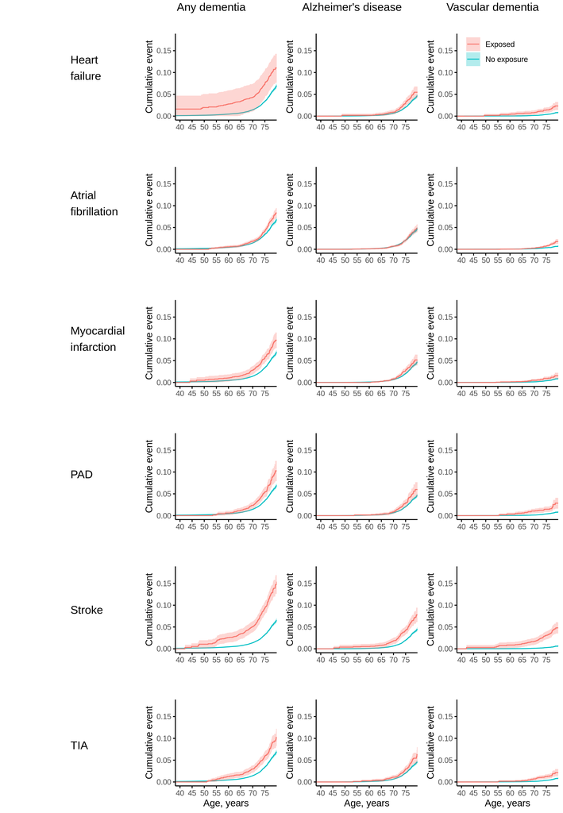

```r
nicenames <- c(DEMENTIA = "Any dementia", ALZHEIMER = "Alzheimer disase", VASCDEM = "Vascular dementia",
               AF_TDC = "Atrial\nfibrillation", OBESITY_TDC = "Obesity",
               HYPLIP_WIDE_TDC = "Hyperlipidemia", HEARTFAIL_ALLCAUSE_TDC="Heart\nfailure",
               MI_TDC = "Myocardial\ninfarction", CHRONKIDNEYDIS_TDC = "Chronic kidney disease",
               HYPERTENSION_TDC = "Hypertension", DIABETES_TDC = "Diabetes", STR_TDC = "Stroke",
               STR_EMBOLIC_TDC = "Embolic stroke", TIA_TDC = "TIA",
               AUD_TDC = "Alcohol abuse", PAD_TDC = "PAD")
fontsize <- 13

#Exposure labels
exp.labs.l <- lapply(as.list(tdc_vars2), function(var){
  text_grob(nicenames[var], just="left", size=fontsize)
})
p0 <- arrangeGrob(grobs=exp.labs.l, ncol=1)

#Dementia
ep="DEMENTIA"
var="AF_TDC"  #Without initialization loop fails, which is strange
my_formula <- str_glue("Surv(tstart, tstop, event) ~ {var}")

plots.kms <-   lapply(as.list(tdc_vars2), function(var){

  my.km <-
    ggsurvplot(km.y.l[[ep]][[var]], fun="event", conf.int=T, censor=F,
       xlim=c(40,78), ylim=c(0,0.18), break.x.by=5, break.y.by=0.05,
       title = "", xlab = "", legend="none", legend.labs=c('No exposure','Exposed'),
       ggtheme = theme_classic(), palette = c("#00BFC4","#F8766D"), size = 0.5)$plot
}) %>% setNames(as.list(tdc_vars2))
#xlab only to bottom row (TIA)
plots.kms$TIA_TDC <- plots.kms$TIA_TDC +
  xlab("Age, years")

p1 <- arrangeGrob(grobs=plots.kms, ncol=1, top=text_grob("Any dementia", size=fontsize))


#Alzheimer
ep="ALZHEIMER"
var="AF_TDC"  #Without initialization loop fails, which is strange
my_formula <- str_glue("Surv(tstart, tstop, event) ~ {var}")

plots.kms <-   lapply(as.list(tdc_vars2), function(var){

  my.km <-
    ggsurvplot(km.y.l[[ep]][[var]], fun="event", conf.int=T, censor=F,
       xlim=c(40,78), ylim=c(0,0.18), break.x.by=5, break.y.by=0.05,
       title = "", xlab = "", legend="none", legend.labs=c('No exposure','Exposed'),
       ggtheme = theme_classic(), palette = c("#00BFC4","#F8766D"), size = 0.5)$plot
}) %>% setNames(as.list(tdc_vars2))
#xlab only to bottom row (TIA)
plots.kms$TIA_TDC <- plots.kms$TIA_TDC +
  xlab("Age, years")

p2 <- arrangeGrob(grobs=plots.kms, ncol=1, top=text_grob("Alzheimer's disease", size=fontsize))

#Vascular dementia
ep="VASCDEM"
var="AF_TDC"  #Without initialization loop fails, which is strange
my_formula <- str_glue("Surv(tstart, tstop, event) ~ {var}")

plots.kms <-   lapply(as.list(tdc_vars2), function(var){

  my.km <-
    ggsurvplot(km.y.l[[ep]][[var]], fun="event", conf.int=T, censor=F,
       xlim=c(40,78), ylim=c(0,0.18), break.x.by=5, break.y.by=0.05,
       title = "", xlab = "", legend="none", legend.labs=c('No exposure','Exposed'),
       ggtheme = theme_classic(), palette = c("#00BFC4","#F8766D"), size = 0.5)$plot
}) %>% setNames(as.list(tdc_vars2))
#xlab only to bottom row (TIA)
plots.kms$TIA_TDC <- plots.kms$TIA_TDC +
  xlab("Age, years")

#Legends fixed
plots.kms$HEARTFAIL_ALLCAUSE_TDC <-
  plots.kms$HEARTFAIL_ALLCAUSE_TDC +
  theme(legend.position = c(0.4,0.82)) +   #Inserted image
  guides(col = guide_legend(reverse = TRUE), fill = guide_legend(reverse = TRUE)) + #Reverse order
  theme(legend.title=element_blank())

p3 <- arrangeGrob(grobs=plots.kms, ncol=1, top=text_grob("Vascular dementia", size=fontsize))

#Combine all
p.grid <- arrangeGrob(p0, p1,p2,p3, ncol=4)


ggsave(file = str_glue("{fig_path}/km.grid.y.png"), plot = p.grid, height = 13, width = 9, dpi = 300)
ggsave(file = str_glue("{fig_path}/km.grid.y.eps"), plot = p.grid, device = cairo_ps, height = 13, width =9, dpi = 300)
```

### 2.2.2 Old

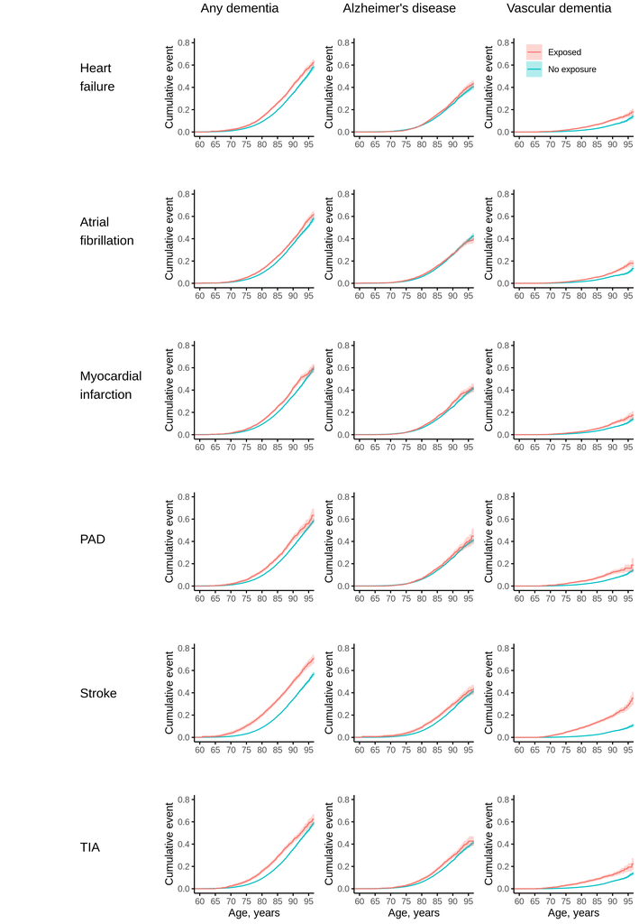

```r
#Exposure labels
exp.labs.l <- lapply(as.list(tdc_vars2), function(var){
  text_grob(nicenames[var], just="left", size=fontsize)
})
p0 <- arrangeGrob(grobs=exp.labs.l, ncol=1)

#Dementia
ep="DEMENTIA"
var="AF_TDC"  #Without initialization loop fails, which is strange
my_formula <- str_glue("Surv(tstart, tstop, event) ~ {var}")

plots.kms <-   lapply(as.list(tdc_vars2), function(var){

  my.km <-
    ggsurvplot(km.o.l[[ep]][[var]], fun="event", conf.int=T, censor=F,
       xlim=c(60,95), ylim=c(0,0.8), break.x.by=5, break.y.by=0.2,
       title = "", xlab = "", legend="none", legend.labs=c('No exposure','Exposed'),
       ggtheme = theme_classic(), palette = c("#00BFC4","#F8766D"), size = 0.5)$plot
}) %>% setNames(as.list(tdc_vars2))
#xlab only to bottom row (TIA)
plots.kms$TIA_TDC <- plots.kms$TIA_TDC +
  xlab("Age, years")

p1 <- arrangeGrob(grobs=plots.kms, ncol=1, top=text_grob("Any dementia", size=fontsize))


#Alzheimer
ep="ALZHEIMER"
var="AF_TDC"  #Without initialization loop fails, which is strange
my_formula <- str_glue("Surv(tstart, tstop, event) ~ {var}")

plots.kms <-   lapply(as.list(tdc_vars2), function(var){

  my.km <-
    ggsurvplot(km.o.l[[ep]][[var]], fun="event", conf.int=T, censor=F,
       xlim=c(60,95), ylim=c(0,0.8), break.x.by=5, break.y.by=0.2,
       title = "", xlab = "", legend="none", legend.labs=c('No exposure','Exposed'),
       ggtheme = theme_classic(), palette = c("#00BFC4","#F8766D"), size = 0.5)$plot
}) %>% setNames(as.list(tdc_vars2))
#xlab only to bottom row (TIA)
plots.kms$TIA_TDC <- plots.kms$TIA_TDC +
  xlab("Age, years")

p2 <- arrangeGrob(grobs=plots.kms, ncol=1, top=text_grob("Alzheimer's disease", size=fontsize))

#Vascular dementia
ep="VASCDEM"
var="AF_TDC"  #Without initialization loop fails, which is strange
my_formula <- str_glue("Surv(tstart, tstop, event) ~ {var}")

plots.kms <-   lapply(as.list(tdc_vars2), function(var){

  my.km <-
    ggsurvplot(km.o.l[[ep]][[var]], fun="event", conf.int=T, censor=F,
       xlim=c(60,95), ylim=c(0,0.8), break.x.by=5, break.y.by=0.2,
       title = "", xlab = "", legend="none", legend.labs=c('No exposure','Exposed'),
       ggtheme = theme_classic(), palette = c("#00BFC4","#F8766D"), size = 0.5)$plot
}) %>% setNames(as.list(tdc_vars2))
#xlab only to bottom row (TIA)
plots.kms$TIA_TDC <- plots.kms$TIA_TDC +
  xlab("Age, years")

#Legends fixed
plots.kms$HEARTFAIL_ALLCAUSE_TDC <-
  plots.kms$HEARTFAIL_ALLCAUSE_TDC +
  theme(legend.position = c(0.4,0.8)) +   #Inserted image
  guides(col = guide_legend(reverse = TRUE), fill = guide_legend(reverse = TRUE)) + #Reverse order
  theme(legend.title=element_blank())

p3 <- arrangeGrob(grobs=plots.kms, ncol=1, top=text_grob("Vascular dementia", size=fontsize))

#Combine all
p.grid <- arrangeGrob(p0, p1,p2,p3, ncol=4)


ggsave(file = str_glue("{fig_path}/km.grid.o.png"), plot = p.grid, height = 13, width = 9, dpi = 300)
ggsave(file = str_glue("{fig_path}/km.grid.o.eps"), plot = p.grid, device = cairo_ps, height = 13, width =9, dpi = 300)
```

**cloglog curves**

**Young**

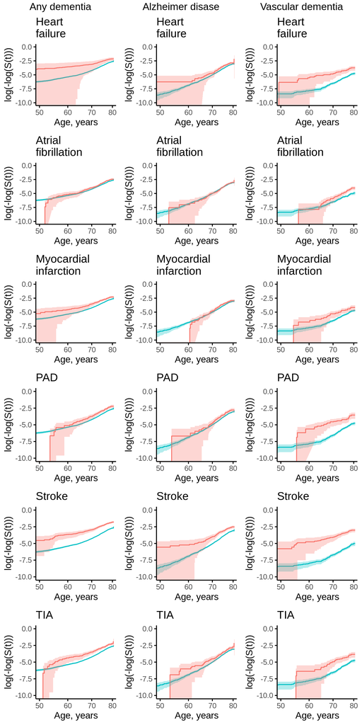

```r
ep="DEMENTIA"
var="AF_TDC"  #Without initialization loop fails, which is strange
my_formula <- str_glue("Surv(tstart, tstop, event) ~ {var}")

plots.tmp.y <- lapply(names_ep, function(ep){

    plots.clogs.y <- lapply(as.list(tdc_vars2), function(var){
      my.km <-
        ggsurvplot(km.y.l[[ep]][[var]], fun="cloglog", conf.int=T, censor=F,
           xlim=c(50,80), ylim=c(-10,0),
           title = nicenames[var], xlab = "Age, years", legend="none",
           ggtheme = theme_classic(), palette = c("#00BFC4","#F8766D"), size = 0.5)$plot +
        scale_x_continuous(trans="log", breaks=c(50, 60, 70, 80, 90))
    })

  arrangeGrob(grobs=plots.clogs.y, ncol=1, top=text_grob(nicenames[ep]))

})%>% setNames(names_ep)

p.grid <- arrangeGrob(grobs=plots.tmp.y, ncol=3)
ggsave(file = str_glue("{fig_path}/log.grid.young.png"), plot = p.grid, height = 12, width = 6, dpi = 300)
```

**Old**

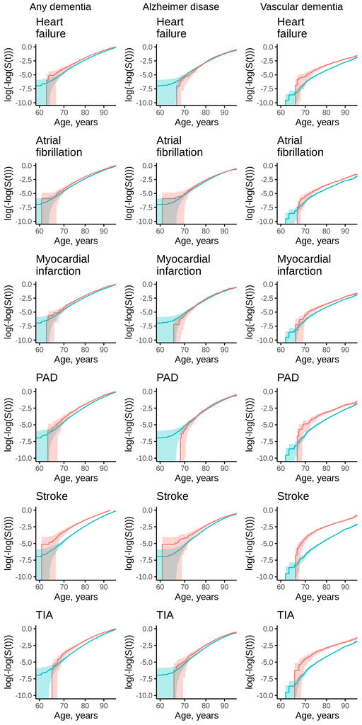

```r
ep="DEMENTIA"
var="AF_TDC"  #Without initialization loop fails, which is strange
my_formula <- str_glue("Surv(tstart, tstop, event) ~ {var}")

plots.tmp.o <- lapply(names_ep, function(ep){

    plots.clogs.o <- lapply(as.list(tdc_vars2), function(var){
      my.km <-
        ggsurvplot(km.o.l[[ep]][[var]], fun="cloglog", conf.int=T, censor=F,
           xlim=c(60,95), ylim=c(-10,0),
           title = nicenames[var], xlab = "Age, years", legend="none",
           ggtheme = theme_classic(), palette = c("#00BFC4","#F8766D"), size = 0.5)$plot +
        scale_x_continuous(trans="log", breaks=c(50, 60, 70, 80, 90))
    })

  arrangeGrob(grobs=plots.clogs.o, ncol=1, top=text_grob(nicenames[ep]))

})%>% setNames(names_ep)

p.grid <- arrangeGrob(grobs=plots.tmp.o, ncol=3)
ggsave(file = str_glue("{fig_path}/log.grid.old.png"), plot = p.grid, height = 12, width = 6, dpi = 300)
```

## 2.3 Cox models

### 2.3.1 Young

**Models**

```r
nicenames <- c(DEMENTIA = " Any dementia", ALZHEIMER = " Alzheimer disase", VASCDEM = " Vascular dementia",
               AF_TDC = " Atrial fibrillation", OBESITY_TDC = " Obesity",
               HYPLIP_WIDE_TDC = " Hyperlipidemia", HEARTFAIL_ALLCAUSE_TDC=" Heart failure",
               MI_TDC = " Myocardial infarction", CHRONKIDNEYDIS_TDC = " Chronic kidney disease",
               HYPERTENSION_TDC = " Hypertension", DIABETES_TDC = " Diabetes", STR_TDC = " Stroke",
               STR_EMBOLIC_TDC = " Embolic stroke", TIA_TDC = " TIA",
               AUD_TDC = " Alcohol abuse", PAD_TDC = " PAD")

#Initialize
ep <-  "DEMENTIA"
cx.table.l.y <- lapply(names_ep, function(x){NULL}) %>% setNames(unlist(names_ep))
cx.full.l.y  <- lapply(names_ep, function(x){NULL}) %>% setNames(unlist(names_ep))

#For each outcome...
for(ep in unlist(names_ep)){

  #Covariate vector to formula format
  oth_covs2_f <- paste(c(oth_covs2), collapse = " + ")
  #print(ep)

  #Models
  cx.l.tdc.y<-
    lapply(as.list(tdc_vars2), function(var){

      my_formula <- str_glue("Surv(tstart, tstop, event) ~ {var} + {oth_covs2_f}")
      coxph(as.formula(my_formula), data=df.list.tdc.y[[ep]])

  }) %>% setNames(tdc_vars2)
 cx.full.l.y[[ep]] <- cx.l.tdc.y

  #Number of exposed
  nN <- df.list.tdc.y[[ep]] %>%
    extract_nN_tdc(ep, tdc_vars2)

  #Table
  cx.table.l.y[[ep]] <- lapply(tdc_vars2, function(var){
    coefs <- cx.l.tdc.y[[var]] %>%
      my_extr_coef(ep, var)
  }) %>% setNames(tdc_vars2) %>%
    reduce(bind_rows) %>%
    mutate(p.adj = p.adjust(pval, method = "fdr", n = length(names_ep)*length(tdc_vars2))) %>%
    left_join(nN, by="names") %>%
    select(name, names, est, lower, upper, pval, p.adj, nN_exp, nN_nexp) %>%
    my_tidy_est2() %>%
    rename(outcome=name, variable=names, mean=est, FDR=p.adj) %>%
    mutate(variable=nicenames[variable])
}
```

**Forest plot**

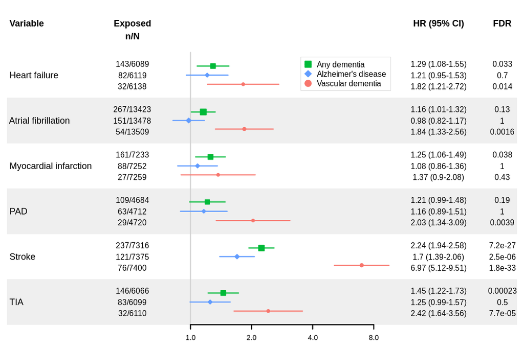

```r
#Stupid hack: forestplot, when grouped, allows only text lines for groups.
#Thus lines within group needs to be combined to same cell and divided by "\n"
tmp <- cx.table.l.y %>%
  reduce(bind_rows) %>%
  select(variable, outcome, nN_exp, FDR, est_ci) %>%
  pivot_wider(names_from=outcome, values_from=c("est_ci", "FDR", "nN_exp")) %>%
  unite(est_ci, matches("est_ci"), sep="\n") %>%
  unite(FDR, matches("FDR"), sep="\n") %>%
  unite(nN_exp, matches("nN"), sep="\n")

cx.table.y <- cx.table.l.y %>%
  reduce(bind_rows) %>%
  select(outcome, variable, mean, lower, upper) %>%
  left_join(tmp, by="variable")

#Forestplot&Table
font.s <- 1.3
font.l <- 1.5
lwd.bar <- 3

forest.y <- cx.table.y %>%
  group_by(outcome) %>%
  forestplot(labeltext = c(variable, nN_exp, est_ci, FDR),
             legend = c("Any dementia", "Alzheimer's disease", "Vascular dementia"),
             legend_args = fpLegend(pos = list(x = .8, y = 0.79),
                                    gp = gpar(col = "#CCCCCC")),
             fn.ci_norm = c(fpDrawNormalCI, fpDrawDiamondCI, fpDrawCircleCI),
             #boxsize = .1, # We set the box size to better visualize the type
             line.margin = .25, # We need to add this to avoid crowding
             graph.pos=3,
             xlog=T,
             shapes_gp = fpShapesGp(default = gpar(lwd = lwd.bar)),
             txt_gp = fpTxtGp(ticks = gpar(cex=font.s-.1),
                              label=list(gpar(cex=font.l), gpar(cex=font.s), gpar(cex=font.s), gpar(cex=font.s)),
                              legend=gpar(cex=font.s),
                              summary = gpar(cex=font.l))
             ) %>%
  fp_add_header(variable= " Variable\n", nN_exp="Exposed\nn/N", est_ci = "HR (95% CI)\n", FDR = "FDR\n") %>%
  fp_set_style(box = c("#00BA38", "#619CFF", "#F8766D"),
               line = c("#00BA38", "#619CFF", "#F8766D"))  %>%
  fp_set_zebra_style("#EFEFEF")

png(str_glue("{fig_path}/forest.y.png"), width = 1050, height = 700)
  forest.y
dev.off()

pdf(str_glue("{fig_path}/forest.y.pdf"), width = 14.7, height = 9.8)
  forest.y
dev.off()
```

### 2.3.2 Old

**Models**

```r
#Initialize
ep <-  "DEMENTIA"
cx.table.l.o <- lapply(names_ep, function(x){NULL}) %>% setNames(unlist(names_ep))
cx.full.l.o  <- lapply(names_ep, function(x){NULL}) %>% setNames(unlist(names_ep))

#For each outcome...
for(ep in unlist(names_ep)){

  #Covariate vector to formula format
  oth_covs2_f <- paste(c(oth_covs2), collapse = " + ")
  #print(ep)

  #Models
  cx.l.tdc.o<-
    lapply(as.list(tdc_vars2), function(var){

      my_formula <- str_glue("Surv(tstart, tstop, event) ~ {var} + {oth_covs2_f}")
      coxph(as.formula(my_formula), data=df.list.tdc.o[[ep]])

  }) %>% setNames(tdc_vars2)
 cx.full.l.o[[ep]] <- cx.l.tdc.o

  #Number of exposed
  nN <- df.list.tdc.o[[ep]] %>%
    extract_nN_tdc(ep, tdc_vars2)

  #Table
  cx.table.l.o[[ep]] <- lapply(tdc_vars2, function(var){
    coefs <- cx.l.tdc.o[[var]] %>%
      my_extr_coef(ep, var)
  }) %>% setNames(tdc_vars2) %>%
    reduce(bind_rows) %>%
    mutate(p.adj = p.adjust(pval, method = "fdr", n = length(names_ep)*length(tdc_vars2))) %>%
    left_join(nN, by="names") %>%
    select(name, names, est, lower, upper, pval, p.adj, nN_exp, nN_nexp) %>%
    my_tidy_est2() %>%
    rename(outcome=name, variable=names, mean=est, FDR=p.adj) %>%
    mutate(variable=nicenames[variable])
}
```

**Forest plots**

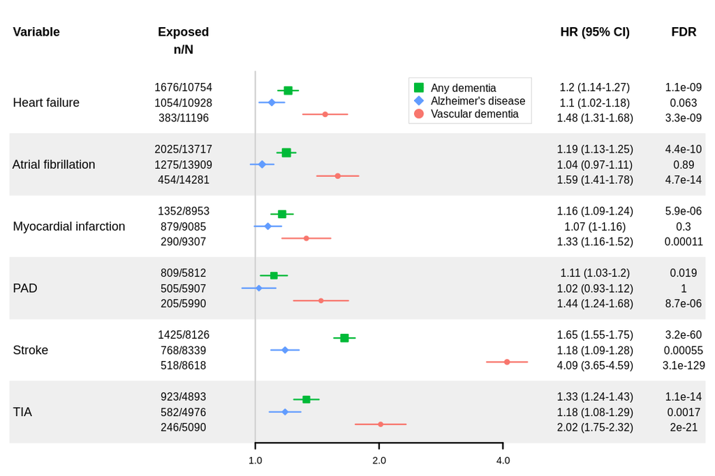

```r
#Stupid hack: forestplot, when grouped, allows only text lines for groups.
#Thus lines within group needs to be combined to same cell and divided by "\n"
tmp <- cx.table.l.o %>%
  reduce(bind_rows) %>%
  select(variable, outcome, nN_exp, FDR, est_ci) %>%
  pivot_wider(names_from=outcome, values_from=c("est_ci", "FDR", "nN_exp")) %>%
  unite(est_ci, matches("est_ci"), sep="\n") %>%
  unite(FDR, matches("FDR"), sep="\n") %>%
  unite(nN_exp, matches("nN"), sep="\n")

cx.table.o <- cx.table.l.o %>%
  reduce(bind_rows) %>%
  select(outcome, variable, mean, lower, upper) %>%
  left_join(tmp, by="variable")

#Forestplot&Table
font.s <- 1.3
font.l <- 1.5
lwd.bar <- 3

forest.o <- cx.table.o %>%
  group_by(outcome) %>%
  forestplot(labeltext = c(variable, nN_exp, est_ci, FDR),
             legend = c("Any dementia", "Alzheimer's disease", "Vascular dementia"),
             legend_args = fpLegend(pos = list(x = .8, y = 0.79),
                                    gp = gpar(col = "#CCCCCC")),
             fn.ci_norm = c(fpDrawNormalCI, fpDrawDiamondCI, fpDrawCircleCI),
             #boxsize = .1, # We set the box size to better visualize the type
             line.margin = .25, # We need to add this to avoid crowding
             graph.pos=3,
             xlog=T,
             shapes_gp = fpShapesGp(default = gpar(lwd = lwd.bar)),
             txt_gp = fpTxtGp(ticks = gpar(cex=font.s-.1),
                              label=list(gpar(cex=font.l), gpar(cex=font.s), gpar(cex=font.s), gpar(cex=font.s)),
                              legend=gpar(cex=font.s),
                              summary = gpar(cex=font.l))
             ) %>%
  fp_add_header(variable= " Variable\n", nN_exp="Exposed\nn/N", est_ci = "HR (95% CI)\n", FDR = "FDR\n") %>%
  fp_set_style(box = c("#00BA38", "#619CFF", "#F8766D"),
               line = c("#00BA38", "#619CFF", "#F8766D"))  %>%
  fp_set_zebra_style("#EFEFEF")

png(str_glue("{fig_path}/forest.o.png"), width = 1050, height = 700)
  forest.o
dev.off()

pdf(str_glue("{fig_path}/forest.o.pdf"), width = 14.7, height = 9.8)
  forest.o
dev.off()
```

**Full output**

Young

```r
cx.full.l.y
```

```
## $DEMENTIA
## $DEMENTIA$HEARTFAIL_ALLCAUSE_TDC
## Call:
## coxph(formula = as.formula(my_formula), data = df.list.tdc.y[[ep]])
##
##                             coef exp(coef)  se(coef)      z        p
## HEARTFAIL_ALLCAUSE_TDC  0.255689  1.291351  0.091981  2.780 0.005439
## BIRTH_YEAR              0.007268  1.007295  0.005922  1.227 0.219693
## SMOKED                  0.089737  1.093887  0.047670  1.882 0.059771
## OBESITY_TDC            -0.098972  0.905768  0.109804 -0.901 0.367401
## HYPLIP_WIDE_TDC         0.241594  1.273277  0.054438  4.438 9.08e-06
## CHRONKIDNEYDIS_TDC      0.139350  1.149526  0.160053  0.871 0.383946
## HYPERTENSION_TDC        0.071971  1.074624  0.054149  1.329 0.183807
## DIABETES_TDC            0.204090  1.226409  0.060509  3.373 0.000744
## AUD_TDC                 1.114716  3.048701  0.077678 14.350  < 2e-16
##
## Likelihood ratio test=266.4  on 9 df, p=< 2.2e-16
## n= 332156, number of events= 1850
##
## $DEMENTIA$AF_TDC
## Call:
## coxph(formula = as.formula(my_formula), data = df.list.tdc.y[[ep]])
##
##                         coef exp(coef)  se(coef)      z        p
## AF_TDC              0.144998  1.156038  0.069346  2.091 0.036533
## BIRTH_YEAR          0.006919  1.006943  0.005921  1.169 0.242583
## SMOKED              0.094508  1.099118  0.047612  1.985 0.047148
## OBESITY_TDC        -0.078768  0.924254  0.109213 -0.721 0.470763
## HYPLIP_WIDE_TDC     0.241818  1.273563  0.054432  4.443 8.89e-06
## CHRONKIDNEYDIS_TDC  0.180550  1.197876  0.158810  1.137 0.255583
## HYPERTENSION_TDC    0.072679  1.075385  0.054197  1.341 0.179914
## DIABETES_TDC        0.214824  1.239644  0.060270  3.564 0.000365
## AUD_TDC             1.119095  3.062081  0.077613 14.419  < 2e-16
##
## Likelihood ratio test=263.3  on 9 df, p=< 2.2e-16
## n= 332156, number of events= 1850
##
## $DEMENTIA$MI_TDC
## Call:
## coxph(formula = as.formula(my_formula), data = df.list.tdc.y[[ep]])
```

[output cut: 273 more lines]

```
## coxph(formula = as.formula(my_formula), data = df.list.tdc.y[[ep]])
##
##                        coef exp(coef) se(coef)      z        p
## TIA_TDC             0.88226   2.41635  0.19824  4.450 8.57e-06
## BIRTH_YEAR         -0.04710   0.95399  0.01935 -2.434  0.01495
## SMOKED              0.46460   1.59137  0.14517  3.200  0.00137
## OBESITY_TDC         0.08240   1.08589  0.26213  0.314  0.75326
## HYPLIP_WIDE_TDC     0.34309   1.40930  0.17053  2.012  0.04423
## CHRONKIDNEYDIS_TDC  0.42075   1.52310  0.34691  1.213  0.22518
## HYPERTENSION_TDC    0.67994   1.97376  0.16132  4.215 2.50e-05
## DIABETES_TDC        0.39087   1.47827  0.16042  2.437  0.01483
## AUD_TDC             1.40939   4.09347  0.19228  7.330 2.30e-13
##
## Likelihood ratio test=149.7  on 9 df, p=< 2.2e-16
## n= 332865, number of events= 213
```

Old

```r
cx.full.l.o
```

```
## $DEMENTIA
## $DEMENTIA$HEARTFAIL_ALLCAUSE_TDC
## Call:
## coxph(formula = as.formula(my_formula), data = df.list.tdc.o[[ep]])
##
##                             coef exp(coef)  se(coef)      z        p
## HEARTFAIL_ALLCAUSE_TDC  0.184035  1.202057  0.029073  6.330 2.45e-10
## BIRTH_YEAR             -0.014474  0.985630  0.002308 -6.270 3.60e-10
## SMOKED                  0.301076  1.351312  0.023480 12.823  < 2e-16
## OBESITY_TDC            -0.148922  0.861636  0.083653 -1.780    0.075
## HYPLIP_WIDE_TDC        -0.020734  0.979480  0.024950 -0.831    0.406
## CHRONKIDNEYDIS_TDC     -0.069196  0.933143  0.069067 -1.002    0.316
## HYPERTENSION_TDC        0.027074  1.027444  0.024190  1.119    0.263
## DIABETES_TDC            0.223788  1.250805  0.027275  8.205 2.31e-16
## AUD_TDC                 0.708584  2.031113  0.055812 12.696  < 2e-16
##
## Likelihood ratio test=545.1  on 9 df, p=< 2.2e-16
## n= 123520, number of events= 7851
##
## $DEMENTIA$AF_TDC
## Call:
## coxph(formula = as.formula(my_formula), data = df.list.tdc.o[[ep]])
##
##                         coef exp(coef)  se(coef)      z        p
## AF_TDC              0.174343  1.190464  0.026765  6.514 7.33e-11
## BIRTH_YEAR         -0.017076  0.983069  0.002306 -7.406 1.30e-13
## SMOKED              0.300949  1.351141  0.023481 12.817  < 2e-16
## OBESITY_TDC        -0.124449  0.882983  0.083435 -1.492    0.136
## HYPLIP_WIDE_TDC    -0.015969  0.984157  0.024922 -0.641    0.522
## CHRONKIDNEYDIS_TDC -0.037764  0.962940  0.068663 -0.550    0.582
## HYPERTENSION_TDC    0.026765  1.027126  0.024182  1.107    0.268
## DIABETES_TDC        0.234735  1.264573  0.027181  8.636  < 2e-16
## AUD_TDC             0.710013  2.034018  0.055803 12.724  < 2e-16
##
## Likelihood ratio test=547.6  on 9 df, p=< 2.2e-16
## n= 123520, number of events= 7851
##
## $DEMENTIA$MI_TDC
## Call:
## coxph(formula = as.formula(my_formula), data = df.list.tdc.o[[ep]])
```

[output cut: 273 more lines]

```
## coxph(formula = as.formula(my_formula), data = df.list.tdc.o[[ep]])
##
##                         coef exp(coef)  se(coef)      z        p
## TIA_TDC             0.702010  2.017805  0.072130  9.733  < 2e-16
## BIRTH_YEAR         -0.043109  0.957807  0.005424 -7.948 1.89e-15
## SMOKED              0.646938  1.909685  0.058081 11.139  < 2e-16
## OBESITY_TDC         0.128094  1.136660  0.171188  0.748    0.454
## HYPLIP_WIDE_TDC    -0.039538  0.961234  0.060380 -0.655    0.513
## CHRONKIDNEYDIS_TDC  0.135864  1.145526  0.142376  0.954    0.340
## HYPERTENSION_TDC    0.399426  1.490969  0.057750  6.916 4.63e-12
## DIABETES_TDC        0.287530  1.333130  0.062075  4.632 3.62e-06
## AUD_TDC             0.864163  2.373020  0.114420  7.553 4.27e-14
##
## Likelihood ratio test=448.4  on 9 df, p=< 2.2e-16
## n= 126634, number of events= 1406
```